# Vivian van Oosten : AM11 Individual Assignment Part 2: Text Mining + PCA

# Introduction

The tags users give to the movies they rate can be very informative. Tags like ‘great’ or ‘terrible’ can help us predict the rating and ultimately determine what movies we want to watch. We can also use the tags to group the movies and see which ones are similar.

In this document we will preprocess the tags data to form a document-term matrix. This matrix will then be used in a Principal Component Analysis to remove any variance that we do not need and reduce the matrix to fewer dimensions. The goal is to prepare the data to use the principal components in machine learning analysis in the future.

# Data Preprocessing

```r
# reading in the data
tags <- fread('ml-25m/tags.csv') %>% select(movieId, tag)
# 1093360 by 2

head(tags)
```

```
##    movieId                  tag
## 1:     260              classic
## 2:     260               sci-fi
## 3:    1732          dark comedy
## 4:    1732       great dialogue
## 5:    7569     so bad it's good
## 6:   44665 unreliable narrators
```

```r
# creating a dataframe tb with all tags for each movie pasted in a single string
# and alss making it all lowercase
tb <- tags %>%
  group_by(movieId) %>%
  summarise(tag = paste0(tag, collapse =" ") )
# 45251 by 2

# filtering for at least 100 words
# by counting the number of spaces, which is the number of
# words in the string. Then we filter to have only movies with 100 or more words
tb <- tb %>%
  mutate(count = str_count(tag, " ") ) %>%
  filter(count > 99) %>%
  select(-count)
# 2918 by 2

# removing special characters from the string
# special characters are defined as any character that
# is not an alphanumeric character
tb <- tb %>%
  mutate(tag = str_replace_all(tag, "[^[:alnum:] ]", ""))
# 2918 by 2

head(tb)
```

```
## # A tibble: 6 × 2
##   movieId tag
##     <int> <chr>
## 1       1 Owned imdb top 250 Pixar Pixar time travel children comedy funny witt…
## 2       2 Robin Williams time travel fantasy based on childrens book board game…
## 3       6 imdb top 250 great acting realistic action suspense Al Pacino atmosph…
## 4       7 remake chauffeur fusion long island millionaire paris sibling relatio…
## 5      10 007 Bond boys with toys gadgets secret service sequel spies violence …
## 6      16 Mafia Mafia Martin Scorsese organized crime robert de niro DeNiro gan…
```

# Text Mining

The preprocessing we are using consists of three parts. Firstly, we remove all special characters and make everything lowercase. This leaves us with just numbers and lowercase letters, which we can process further. Second, we will remove all stopwords. These are words such as ‘the’, ‘as’, and ‘in’. These do not add any information to our data but could be used regularly for all movies. Lastly, we stem all of the entries. This will ensure that words are brought back to their ‘stem’, which for example turns loved lover loving lovely all into love. Because they all represent the same idea, it’s best to combine them into one word and not flood our analysis with many different words.

```r
# Creates the corpus we will be using to make the DTM
tb <- tb %>%
  rename_at('movieId', ~'doc_id') %>%
    rename_at('tag', ~'text') %>%
  mutate(doc_id = as.character(doc_id))
x <- Corpus(VectorSource(tb$text))
```

```r
# making everything lower-case, remove stop words,
# remove punctuation, removing excess whitespace,
# removing numbers and stemming the document
# in that order
x <- tm_map(x, tolower)
x <- tm_map(x,removeWords, stopwords("english"))
x <- tm_map(x,removePunctuation)
#x <- tm_map(x, stripWhitespace)
x <- tm_map(x,removeNumbers)
x <- tm_map(x,stemDocument, language = "english")
```

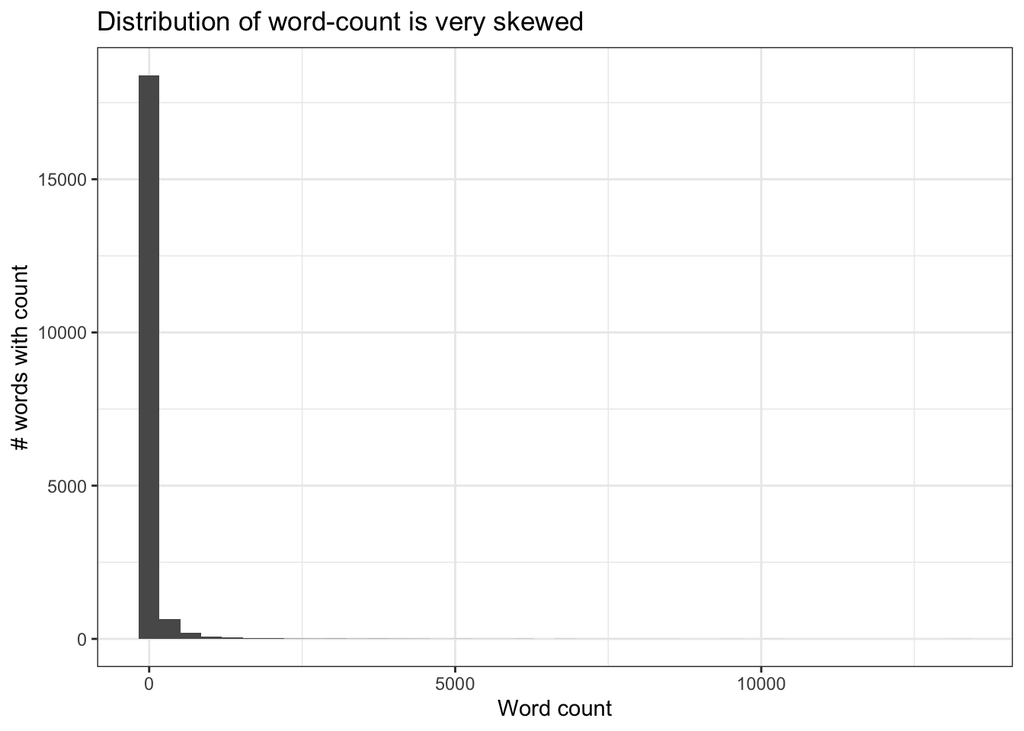

```r
# creating the document term matrix
DTM <- DocumentTermMatrix(x)

# First we see what the document term matrix looks like without removing sparse terms
m <- as.matrix(DTM)
DTM_tbl <- as_tibble(m)
DTM_tidy <- pivot_longer(DTM_tbl, cols = everything(), names_to = "word", values_to = "wordCount")
DTM_tidy %>%
  group_by(word) %>%
  summarise(wordCount = sum(wordCount)) %>%

# plotting the word-count frequencies
ggplot(aes(x = wordCount)) +
  geom_histogram(bins = 40) +
  theme_bw() +
  labs(
    title = 'Distribution of word-count is very skewed',
    y = '# words with count',
    x = 'Word count'
  )
```

Most words have a very very low word count, which means they were only used in very few words. We do not want to keep these extremely sparse terms in our matrix, because they do not add any information. We would also not be able to generalise based on so few instances of the word.

However, we will remove sparse words that occur in less than 2% of the movies. We set this limit very high, because our PCA will already remove the unnecessary variance, which includes very sparse terms that are uninformative. Therefore, we can keep them in case there is information that we need.

```r
# now removing sparse terms from the DTM and redoing the creation of the dataframe
DTM <- removeSparseTerms(DTM, 0.98)
movieIds <- seq(1, nrow(tb), 1)
rownames(DTM) <- movieIds

m <- as.matrix(DTM)
DTM_tbl <- as_tibble(m)
DTM_tidy <- pivot_longer(DTM_tbl, cols = everything(), names_to = "word", values_to = "wordCount")

print(head(DTM_tbl))
```

```
## # A tibble: 6 × 699
##     act action adventur american  anim   art bdvideo  best   boy   buy cartoon
##   <dbl>  <dbl>    <dbl>    <dbl> <dbl> <dbl>   <dbl> <dbl> <dbl> <dbl>   <dbl>
## 1     1      3       14        1   124     1       1     1     4     1       8
## 2     0      1        4        0    14     0       0     0     0     0       0
## 3    33     39        0        0     0     0       0     0     0     0       0
## 4     0      0        0        0     0     0       0     0     0     0       0
## 5     0      4        1        0     0     0       1     1     1     0       0
## 6     0      0        0        0     0     0       1     0     0     0       0
## # … with 688 more variables: cgi <dbl>, childish <dbl>, children <dbl>,
## #   classic <dbl>, clever <dbl>, clv <dbl>, come <dbl>, comedi <dbl>,
## #   comput <dbl>, cute <dbl>, day <dbl>, disney <dbl>, dvdvideo <dbl>,
## #   everi <dbl>, famili <dbl>, fantasi <dbl>, favorit <dbl>, featur <dbl>,
## #   film <dbl>, first <dbl>, friend <dbl>, friendship <dbl>, fun <dbl>,
## #   funni <dbl>, good <dbl>, great <dbl>, heart <dbl>, humor <dbl>, imdb <dbl>,
## #   itaeg <dbl>, jealousi <dbl>, john <dbl>, kid <dbl>, life <dbl>, …
```

```r
print(head(DTM_tidy))
```

```
## # A tibble: 6 × 2
##   word     wordCount
##   <chr>        <dbl>
## 1 act              1
## 2 action           3
## 3 adventur        14
## 4 american         1
## 5 anim           124
## 6 art              1
```

# Exploratory Analysis

Before we start the PCA, we explore the data a little.

First, we print the words with the highest and lowest frequency. This gives us an idea of the kind of words that could end up being important in our analysis.

```r
# we check the word frequency of highest and lowest words
DTM_tidy %>%
  group_by(word) %>%
  summarise(wordCount = sum(wordCount)) %>%
  arrange(wordCount) %>%
  head(10)
```

```
## # A tibble: 10 × 2
##    word     wordCount
##    <chr>        <dbl>
##  1 kaf             62
##  2 congress        64
##  3 etaeg           67
##  4 jussan          67
##  5 buy             70
##  6 lrc             70
##  7 bgab            71
##  8 less            71
##  9 ummarti         71
## 10 gfei            72
```

```r
DTM_tidy %>%
  group_by(word) %>%
  summarise(wordCount = sum(wordCount)) %>%
  arrange(-wordCount) %>%
  head(10)
```

```
## # A tibble: 10 × 2
##    word   wordCount
##    <chr>      <dbl>
##  1 comedi     13262
##  2 end        10262
##  3 scifi       9623
##  4 dark        8577
##  5 base        8254
##  6 great       7868
##  7 action      7369
##  8 twist       7283
##  9 visual      6849
## 10 book        6757
```

The words with the highest frequency are comedy, end and sci-fi. Considering those can describe a large number of movies, this is not a surprising result.

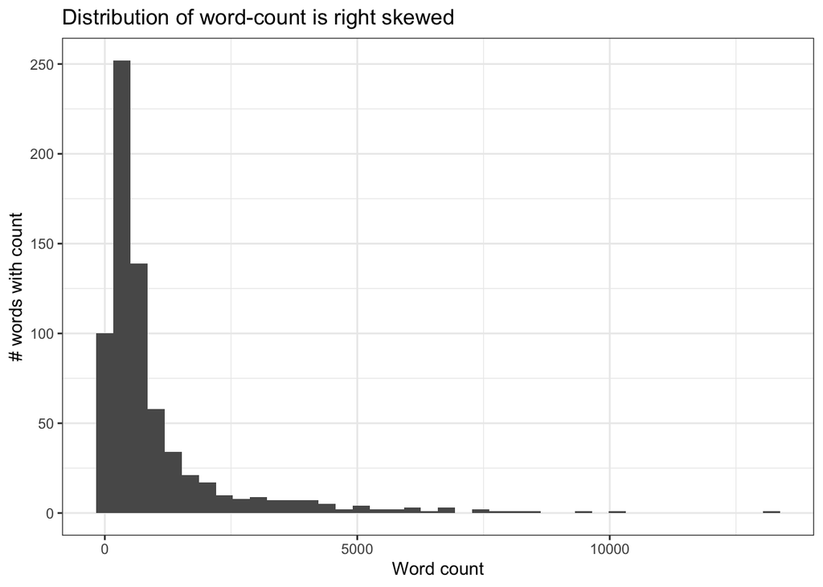

```r
DTM_tidy %>%
  group_by(word) %>%
  summarise(wordCount = sum(wordCount)) %>%

ggplot(aes(x = wordCount)) +
  geom_histogram(bins = 40) +
  theme_bw() +
  labs(
    title = 'Distribution of word-count is right skewed',
    y = '# words with count',
    x = 'Word count'
  )
```

Most words have a word-count bewteen 0 and 2500. It’s likely that these words will hold the most information. However, some words, such as ‘great’, have been used very frequently and can also be very informative for the rating of that movie. Therefore, we do not want to use TF-IDF to weight the words with. The amount that a word occurs for other movies does not influence the importance that the word has for one specific movie in this case.

# Principle Component Analysis

In order to further reduce the dimensionality of the data and create a dataset we could comfortable use for SVM, we run a PCA on the document term matrix. We started out with 699 columns in our Document Term Matrix.

In our preprocessing, we center the data to 0 but we do not scale it, since scaling the data makes the PCA perform much worse. With scaling, it only explains 10% of the variance with 5 columns, while without scaling it explains over 40%. This is also related to our decision not to use tfifd, since scaling the data would perform a similar role.

```r
dim(DTM_tbl) # 2918 699
```

```
## [1] 2918  699
```

```r
DTM_tbl <- scale(DTM_tbl, center = TRUE, scale = FALSE)
pca <- prcomp(DTM_tbl, center = FALSE, scale. = FALSE)
# printing the importance of the first 50 components
summary(pca)$importance[, 1:50]
```

```
##                             PC1      PC2      PC3      PC4      PC5      PC6
## Standard deviation     40.46026 32.04843 24.21649 20.18779 17.85784 15.00684
## Proportion of Variance  0.17190  0.10785  0.06158  0.04280  0.03349  0.02365
## Cumulative Proportion   0.17190  0.27975  0.34133  0.38413  0.41761  0.44126
##                             PC7      PC8      PC9     PC10     PC11     PC12
## Standard deviation     14.65558 13.90444 13.28915 12.93852 12.61555 12.36833
## Proportion of Variance  0.02255  0.02030  0.01854  0.01758  0.01671  0.01606
## Cumulative Proportion   0.46381  0.48412  0.50266  0.52024  0.53695  0.55301
##                            PC13     PC14     PC15     PC16     PC17    PC18
## Standard deviation     11.51083 11.31119 10.81469 10.63653 10.23873 9.98563
## Proportion of Variance  0.01391  0.01343  0.01228  0.01188  0.01101 0.01047
## Cumulative Proportion   0.56693  0.58036  0.59264  0.60452  0.61553 0.62600
##                            PC19     PC20     PC21     PC22     PC23     PC24
## Standard deviation     9.783787 9.515822 8.997503 8.566661 8.421589 8.193658
## Proportion of Variance 0.010050 0.009510 0.008500 0.007710 0.007450 0.007050
## Cumulative Proportion  0.636050 0.645560 0.654060 0.661770 0.669220 0.676270
##                           PC25     PC26     PC27     PC28     PC29     PC30
## Standard deviation     8.08918 7.749362 7.560164 7.448284 7.403369 7.340293
## Proportion of Variance 0.00687 0.006310 0.006000 0.005830 0.005760 0.005660
## Cumulative Proportion  0.68314 0.689440 0.695440 0.701270 0.707030 0.712680
##                            PC31     PC32     PC33    PC34     PC35     PC36
## Standard deviation     7.134462 7.094148 6.951397 6.77560 6.702684 6.691871
## Proportion of Variance 0.005340 0.005280 0.005070 0.00482 0.004720 0.004700
## Cumulative Proportion  0.718030 0.723310 0.728390 0.73321 0.737930 0.742630
##                            PC37     PC38    PC39     PC40    PC41    PC42
## Standard deviation     6.525036 6.454447 6.33102 6.247908 6.09340 6.02627
## Proportion of Variance 0.004470 0.004370 0.00421 0.004100 0.00390 0.00381
## Cumulative Proportion  0.747100 0.751470 0.75568 0.759780 0.76368 0.76749
##                            PC43     PC44     PC45     PC46     PC47    PC48
## Standard deviation     5.878318 5.819718 5.728027 5.701079 5.612922 5.56635
## Proportion of Variance 0.003630 0.003560 0.003450 0.003410 0.003310 0.00325
## Cumulative Proportion  0.771120 0.774680 0.778120 0.781540 0.784840 0.78810
##                            PC49     PC50
## Standard deviation     5.482919 5.299103
## Proportion of Variance 0.003160 0.002950
## Cumulative Proportion  0.791250 0.794200
```

The table shows part of the story, but to choose the optimal number of columns, we use the below visualisation of variance explained as well.

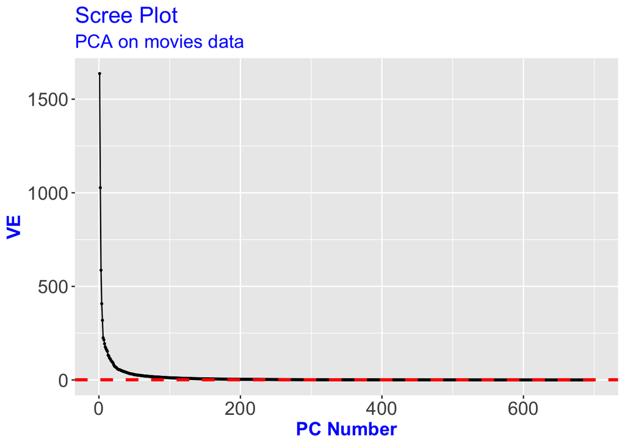

```r
VE <- pca$sdev^2
PVE <- VE / sum(VE) * 100
CPVE <- cumsum(PVE)
df <- data.frame(PC = c(1:699),
                 var_explained = VE,
                 cum_sum_PVE = CPVE)

# --- VARIANCE EXPAINED (SCREEPLOT), VE:
M <- 699
df[1:M,] %>% # select M PCs (rows) and all columns of the dataframe to pass into ggplot
  ggplot(aes(x = PC, y = var_explained)) +
  geom_point(size = 0.5) +
  geom_line() +
  geom_hline(yintercept = 1, linetype = "dashed", color = "red", size = 1.2) +
  labs(x = "PC Number", y = "VE",
       title = "Scree Plot",
       subtitle = "PCA on movies data") +
  theme(axis.text = element_text(size = 15),
        axis.title = element_text(size = 15, face = "bold", color = "blue"),
        plot.title = element_text(size = 18, color = "blue"),
        plot.subtitle = element_text(size = 15, color = "blue") )
```

Clearly the additional relevance of columns decreases very quickly. Below we take a closer look at the plot to determine the exact dimensions we want to take. We select a PC number between 0 and 150, since somewhere before there the elbow occurs that we want to take.

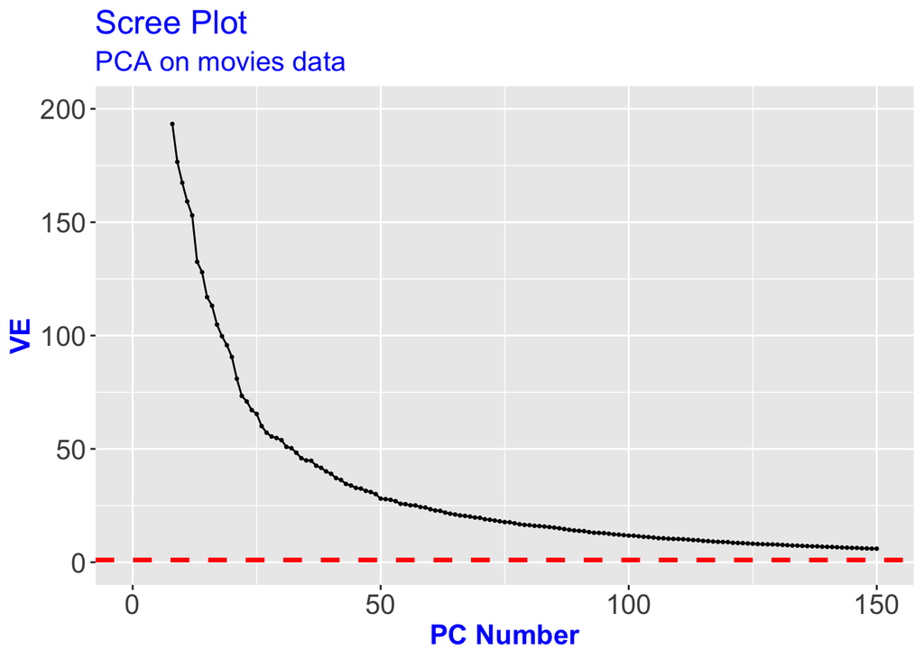

```r
# --- VARIANCE EXPAINED (SCREEPLOT), VE:
M <- 699
df[1:M,] %>% # select M PCs (rows) and all columns of the dataframe to pass into ggplot
  ggplot(aes(x = PC, y = var_explained)) +
  geom_point(size = 0.5) +
  geom_line() +
  scale_x_continuous(limits = c(0, 150) ) +
  scale_y_continuous(limits = c(0, 200)) +
  geom_hline(yintercept = 1, linetype = "dashed", color = "red", size = 1.2) +
  labs(x = "PC Number", y = "VE",
       title = "Scree Plot",
       subtitle = "PCA on movies data") +
  theme(axis.text = element_text(size = 15),
        axis.title = element_text(size = 15, face = "bold", color = "blue"),
        plot.title = element_text(size = 18, color = "blue"),
        plot.subtitle = element_text(size = 15, color = "blue") )
```

We select these features so that we could use them in the analysis from here on out.

```r
# selecting only the features we want
pca_features <- pca$x[, 1:25]

# to use the features later, we have saved them to an RDS object
#saveRDS(pca_features, 'part2_pca_features_object.rds')
```